# Looking for better tips? Go to…

Andrea Celleri

According to an article by Trip Savvy, drivers in New York City should be tipped an average of 10 to 20 percent of the total cost of a ride. Most of the time, this amount is automatically calculated based on the cost of the fare. However, this value is not fixed and can change if the expectations of the passenger are not meet by the quality of the overall ride.

To look deeper into what variables impact the total percentage tip for a New York City taxi ride, the taxi dataset was analyzed. The data show that in contrast with the advice, the overall percentage of tip for taxi rides in New York City is above 20 percent. Furthermore, percentage tip has a negative correlation with the total cost of the trip and can vary by borough location.

The dataset was analyzed in three distinct ways; in a macro level, by borough level, and by looking at rides from La Guardia Airport. First, at a macro level, the average percentage tip for taxi rides in the entire New York City area was off 24.50 percent of the total trip. There is an overall decreasing trend of the percentage tip as the total cost of the ride increases. A possible explanation for this is customers paying with cash for rides under 20 dollars round up their tip to avoid change. Consequently, for lower total fare amount, rounding up to the nearest dollar has a more significant influence on the overall percentage tip than for more substantial fares.

```
##
## Call:
## lm_basic(formula = tip_percent * 100 ~ 1 + borough_dropoff +
##     fare_amount, data = taxi_nta)
##
## Residuals:
##     Min      1Q  Median      3Q     Max
## -27.072  -2.115   0.101   2.216 174.786
##
## Coefficients:
##                              Estimate   2.5 % 97.5 %
## (Intercept)                   24.6166 24.4298 24.803
## borough_dropoffBrooklyn       -0.1310 -0.3202  0.058
## borough_dropoffManhattan      -0.8613 -1.0472 -0.675
## borough_dropoffQueens          2.8063  2.6172  2.995
## borough_dropoffStaten Island   8.2589  7.4644  9.053
## borough_dropoffUnknown         3.2411  3.0407  3.441
## fare_amount                   -0.1542 -0.1550 -0.153
##
## Residual standard error: 7.582 on 5631822 degrees of freedom
##   (8866 observations deleted due to missingness)
## Multiple R-squared:  0.02808,    Adjusted R-squared:  0.02808
## F-statistic: 2.712e+04 on 6 and 5631822 DF,  p-value: < 2.2e-16
```

On the following graph, the previously mentioned trend is visible. When the total fare is under 20 dollars, the percentage tip is primarily 20 to 25 percent. Moreover, when the entire fare is between 20 to 40 dollars, the most common tip is between 15 to 20 percent. (Tips that are higher than 25 percent of the total fare are concentrated around 50 dollars and 70 dollar rides. Again, this trend could be driven by people rounding up their tips to 15 dollars and 20 dollars accordingly.)

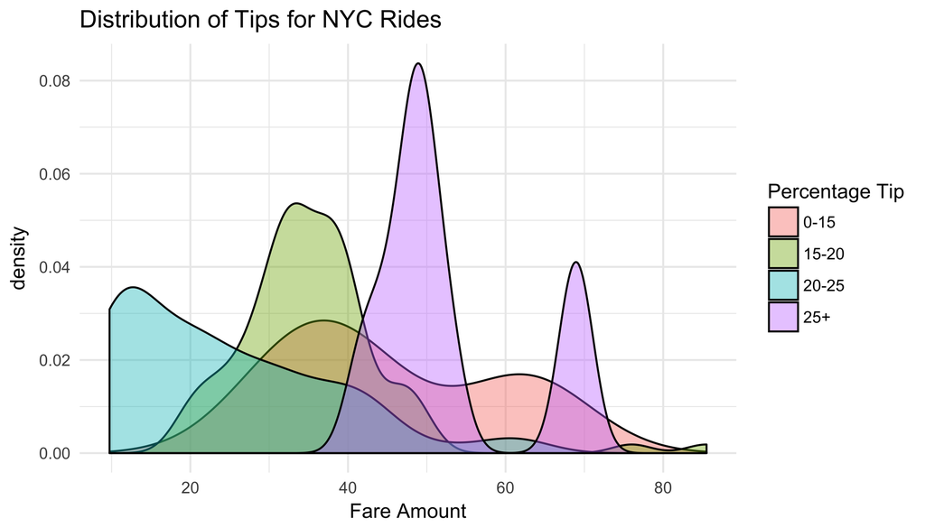

Next, the percentage tip by borough was analyzed by looking at the five boroughs in New York City; Bronx, Brooklyn, Manhattan, Queens, and Staten Island. Out of these, Manhattan’s overall tip is the lowest with 0.86 percent less than the average percentage tip for the city. On the other hand, Queens and Staten Island both have significantly higher percentage tips of 2.81 percent and 8.25 percent above the city’s mean.

Furthermore, Manhattan was analyzed since it has a smaller mean percentage tip and has significantly more rides than the other zones. The following plot displays all taxi rides that were dropped off in the Manhattan area by zone. As displayed in yellow, the mean percentage tip is 20 to 25 percent for rides that are lower than 17.5 dollars.

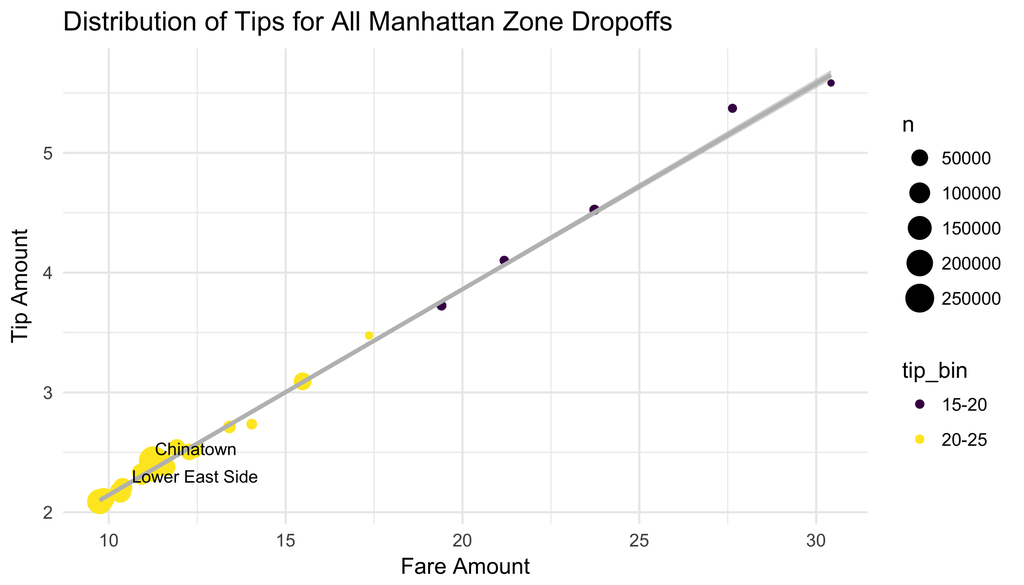

Finally, by looking only at rides leaving La Guardia Airport with a Manhattan destination, the percentage tip by neighborhood and zone was analyzed. This limited the impact of other variables that could indirectly be influencing the percentage of tip. By segmenting the Manhattan area into five neighborhoods, we found that the Upper West Side has the highest percentage tip. However, it has a total median fare of $32.06 which is not the lowest in the area. The actual lowest mean fare for rides coming from La Guardia is for Uptown Manhattan (which makes sense given the proximity of the neighborhood to the airport). However, Uptown has a percentage tip of 22.19 percent, which is the lowest among the Manhattan neighborhoods.

The graph below shows the distribution of tips for rides from La Guardia Airport into zones in Manhattan. Battery Park, located at the southern tip of the Manhattan Island, stands out since it has the highest average fare price for all zones. On the other hand, East Harlem North has the lowest average fare price and the highest percentage of tip.

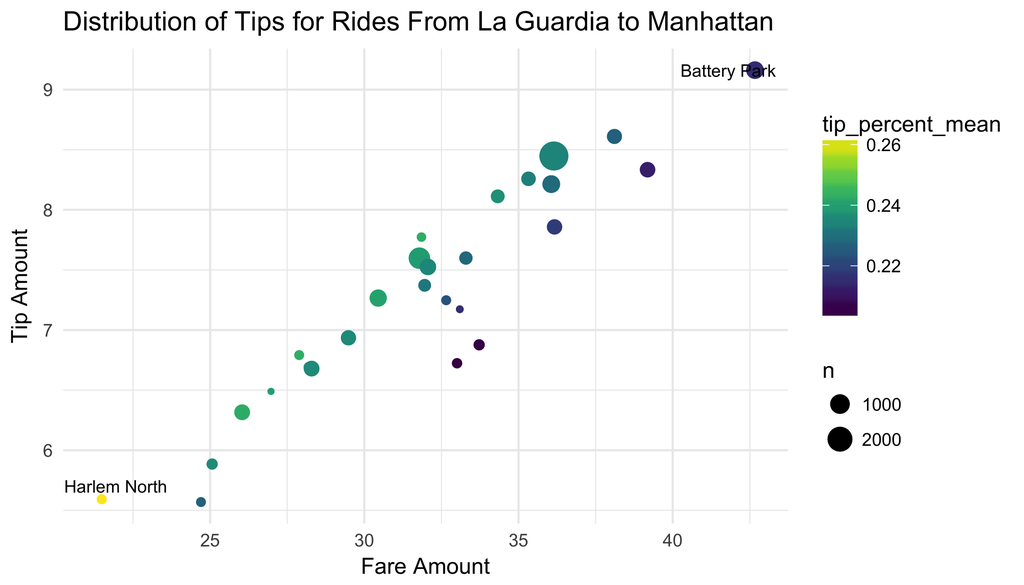

Much more time is needed to understand what drives tips for New York City taxi rides. However, from this short analysis we can conclude that in most cases, the higher the cost of the ride the lower the percentage of tips is. Furthermore, a taxi dropping of customers in Queens, and Staten Island tend to receive higher tips. In Manhattan, the Upper West Side might provide higher tips (specially coming from La Guardia Airport). Yet, La Guardia rides might have a large percentage of tourists that do not represent the New York population.

## References

Cross, Heather. “Who (and How Much) Should You Tip in NYC?” TripSavvy, 7 July 2011, www.tripsavvy.com/nyc-tipping-etiquette-1613219.